# Machine Learning application----Census Income Prediction

# Age column

```python
#data['Age'].unique()
```

```python
We create a distribution plot for the age column
```

```python
import seaborn as sns
import warnings
warnings.filterwarnings('ignore')
```

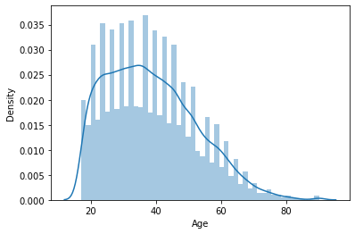

```python
sns.distplot(data.Age)
```

# Fnlwgt column

```python
data['Fnlwgt'].unique
```

```
<bound method Series.unique of 0         83311
1        215646
2        234721
3        338409
4        284582
          ...
32555    257302
32556    154374
32557    151910
32558    201490
32559    287927
Name: Fnlwgt, Length: 32560, dtype: int64>
```

# Workclass column

```python
plt
```

[output not shown]

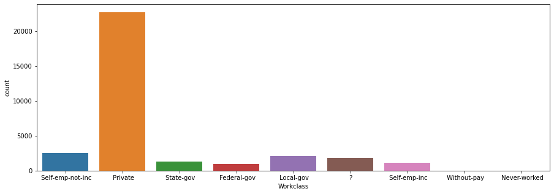

```python
plt.figure(figsize=(15,5))
sns.countplot(data['Workclass'])
```

We observe that majority of the people belong to ‘Private’ sector workclass.

# Education column

The ‘Education’ column has 16 different categories available. Majority of these categories belong to ‘School’ type (different classes are divided into multiple categories)

```
(array([ 0,  1,  2,  3,  4,  5,  6,  7,  8,  9, 10, 11, 12, 13, 14, 15]),
 [Text(0, 0, ' Bachelors'),
```

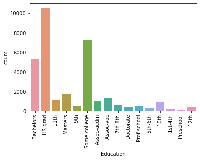

```python
sns.countplot(data.Education)
plt.xticks(rotation=90)
```

We observe no missing values in this column, and also find out that majority of the people have education level as ‘HS-grad’, followed by ‘Some-college’ and ‘Bachelors’

# Education_num column

The education number is the number of years for which a person received education. This is an ordinal column, which contains 16 different values. When we check the division of ‘Education_num’ column, we observe that the count of ‘Education’ column and ‘Education_num’ is exactly same! Which means, the ‘Education_num’ column is providing same information as ‘Education’ column, but in a numeric manner!

```
(array([ 0,  1,  2,  3,  4,  5,  6,  7,  8,  9, 10, 11, 12, 13, 14, 15]),
 [Text(0, 0, '1'),
```

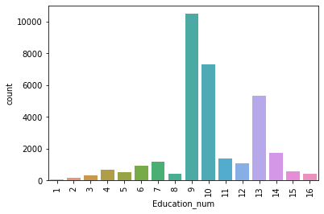

```python
sns.countplot(data.Education_num)
plt.xticks(rotation=90)
```

# Marital_Status column

```python
The ‘Marital_Status’ column has 7 different categories available, and has no missing values.
```

```
(array([0, 1, 2, 3, 4, 5, 6]),
 [Text(0, 0, ' Married-civ-spouse'),
```

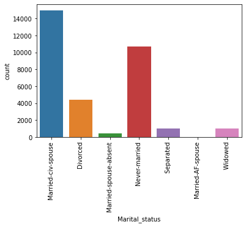

```python
sns.countplot(data.Marital_status)
plt.xticks(rotation = 90)
```

Majority of the people have ‘Marital_Status’ as ‘Married-civ-spouse’, and least have ‘Married-AF-spouse’.

Count of ‘Never-married’ is also quite high.

```python
data.info()
```

```
<class 'pandas.core.frame.DataFrame'>
RangeIndex: 32560 entries, 0 to 32559
Data columns (total 15 columns):
 #   Column          Non-Null Count  Dtype
---  ------          --------------  -----
 0   Age             32560 non-null  int64
 1   Workclass       32560 non-null  object
 2   Fnlwgt          32560 non-null  int64
 3   Education       32560 non-null  object
 4   Education_num   32560 non-null  int64
 5   Marital_status  32560 non-null  object
 6   Occupation      32560 non-null  object
 7   Relationship    32560 non-null  object
 8   Race            32560 non-null  object
 9   Sex             32560 non-null  object
 10  Capital_gain    32560 non-null  int64
 11  Capital_loss    32560 non-null  int64
 12  Hours_per_week  32560 non-null  int64
 13  Native_country  32560 non-null  object
 14  Income          32560 non-null  object
dtypes: int64(6), object(9)
memory usage: 3.7+ MB
```

# Occupation column

```
(array([ 0,  1,  2,  3,  4,  5,  6,  7,  8,  9, 10, 11, 12, 13, 14]),
 [Text(0, 0, ' Prof-specialty'),
```

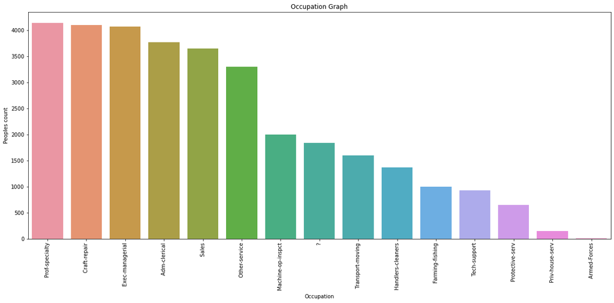

```python
plt.figure(figsize=(20,8))
sns.countplot(data['Occupation'],order=data['Occupation'].value_counts().index)
plt.title('Occupation Graph')
plt.ylabel('Peoples count')
plt.xticks(rotation=90)
```

# Relationship column

The relationship column contains 6 different types of values, with highest number set for ‘Husband’ and lowest for ‘Other-relative’. The column does not have any missing value.

```
(array([0, 1, 2, 3, 4, 5]),
 [Text(0, 0, ' Husband'),
```

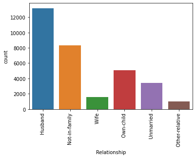

```python
sns.countplot(data.Relationship)
plt.xticks(rotation = 90)
```

# Race column

The Race column has 5 different categories, and no missing data. Highest number of people have race as ‘White’ (significantly high numbers).

```
(array([0, 1, 2, 3, 4]),
 [Text(0, 0, ' White'),
```

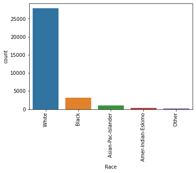

```python
sns.countplot(data.Race)
plt.xticks(rotation=90)
```

```
(array([0, 1]), [Text(0, 0, ' Male'), Text(1, 0, ' Female')])
```

[figure not shown]

```python
sns.countplot(data.Sex)
plt.xticks(rotation=90)
```

# Sex column

The ‘Sex’ column has 2 categories — Male and Female, where number of males are almost double to number of females. Missing values are not found in this column.

```
(array([0, 1]), [Text(0, 0, ' Male'), Text(1, 0, ' Female')])
```

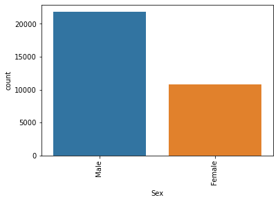

```python
sns.countplot(data.Sex)
plt.xticks(rotation=90)
```

# Capital gain column

‘Capital_gain’ column is a numeric column, with majority of the values set as 0. The distribution plot for ‘Capital_gain’ column is highly right skewed.

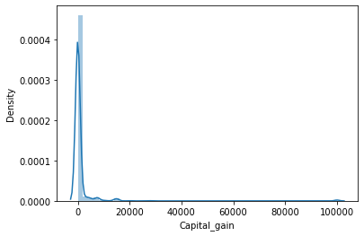

```python
sns.distplot(data.Capital_gain)
```

# Hours per week column

The hours per week column has values scattered over a range of 1–99. The column does not have any missing values. Majority of the values have data near 40 hours and hence a high peak can be observed in the below distribution plot –

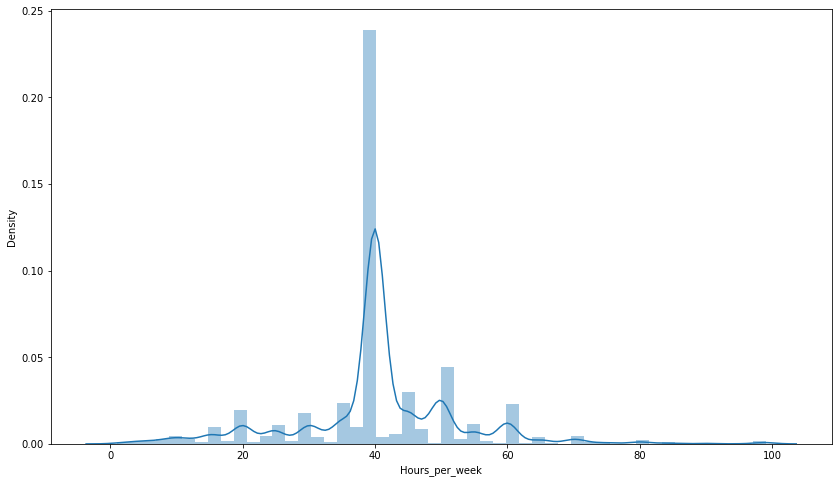

```python
plt.figure(figsize=(14,8))
sns.distplot(data.Hours_per_week)
```

# Native_country column

The Native_country column contains the highest count set to ‘United-States’, and rest of the rows contain quite few numbers (highest count after US is 643).

```python
data['Native_country'].unique()
```

```
array([' United-States', ' Cuba', ' Jamaica', ' India', ' ?', ' Mexico',
       ' South', ' Puerto-Rico', ' Honduras', ' England', ' Canada',
       ' Germany', ' Iran', ' Philippines', ' Italy', ' Poland',
       ' Columbia', ' Cambodia', ' Thailand', ' Ecuador', ' Laos',
       ' Taiwan', ' Haiti', ' Portugal', ' Dominican-Republic',
       ' El-Salvador', ' France', ' Guatemala', ' China', ' Japan',
       ' Yugoslavia', ' Peru', ' Outlying-US(Guam-USVI-etc)', ' Scotland',
       ' Trinadad&Tobago', ' Greece', ' Nicaragua', ' Vietnam', ' Hong',
       ' Ireland', ' Hungary', ' Holand-Netherlands'], dtype=object)
```

```
(array([ 0,  1,  2,  3,  4,  5,  6,  7,  8,  9, 10, 11, 12, 13, 14, 15, 16,
        17, 18, 19, 20, 21, 22, 23, 24, 25, 26, 27, 28, 29, 30, 31, 32, 33,
        34, 35, 36, 37, 38, 39, 40, 41]),
 [Text(0, 0, ' United-States'),
```

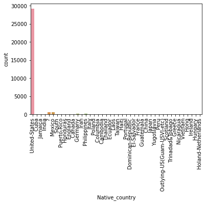

```python
sns.countplot(data.Native_country)
plt.xticks(rotation=90)
```

```python
We further check how the income gets impacted due to the features which we just explored
```

[output not shown]

[output not shown]

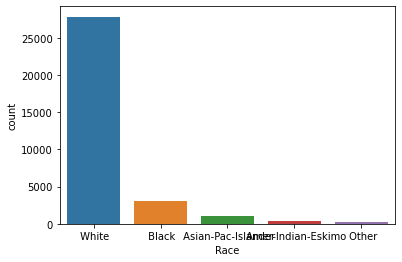

```python
sns.countplot(data['Race'])
```

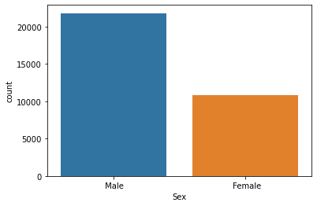

```python
sns.countplot(data['Sex'])
```

```
(array([0, 1, 2, 3, 4, 5, 6, 7, 8]),
 [Text(0, 0, ' Self-emp-not-inc'),
```

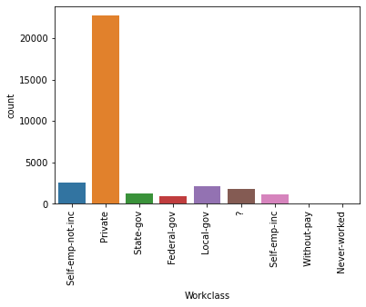

```python
sns.countplot(data['Workclass'])
plt.xticks(rotation=90)
```

```
(array([ 0,  1,  2,  3,  4,  5,  6,  7,  8,  9, 10, 11, 12, 13, 14, 15, 16,
        17, 18, 19, 20, 21, 22, 23, 24, 25, 26, 27, 28, 29, 30, 31, 32, 33,
        34, 35, 36, 37, 38, 39, 40, 41, 42, 43, 44, 45, 46, 47, 48, 49, 50,
        51, 52, 53, 54, 55, 56, 57, 58, 59, 60, 61, 62, 63, 64, 65, 66, 67,
        68, 69, 70, 71, 72]),
 [Text(0, 0, '17'),
```

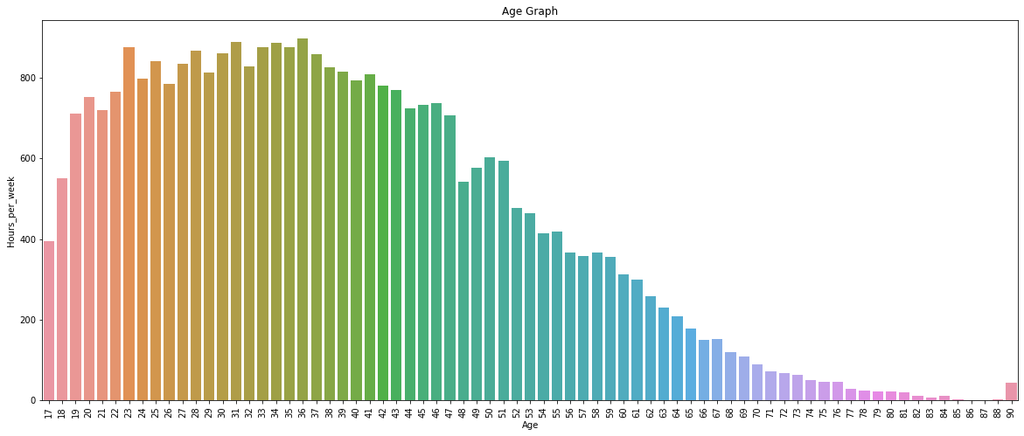

```python
plt.figure(figsize=(20,8))
sns.countplot(data['Age'])
plt.title('Age Graph')
plt.ylabel('Hours_per_week')
plt.xticks(rotation=90)
```

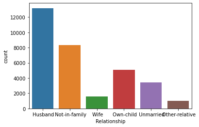

```python
sns.countplot(data.Relationship)
```

```python
from sklearn.preprocessing import LabelEncoder
le=LabelEncoder()
```

```python
data['Income']=le.fit_transform(data['Income'])
```

```python
data.head()
```

|  | Age | Workclass | Fnlwgt | Education | Education_num | Marital_status | Occupation | Relationship | Race | Sex | Capital_gain | Capital_loss | Hours_per_week | Native_country | Income |
| --- | --- | --- | --- | --- | --- | --- | --- | --- | --- | --- | --- | --- | --- | --- | --- |
| 0 | 50 | Self-emp-not-inc | 83311 | Bachelors | 13 | Married-civ-spouse | Exec-managerial | Husband | White | Male | 0 | 0 | 13 | United-States | 0 |
| 1 | 38 | Private | 215646 | HS-grad | 9 | Divorced | Handlers-cleaners | Not-in-family | White | Male | 0 | 0 | 40 | United-States | 0 |
| 2 | 53 | Private | 234721 | 11th | 7 | Married-civ-spouse | Handlers-cleaners | Husband | Black | Male | 0 | 0 | 40 | United-States | 0 |
| 3 | 28 | Private | 338409 | Bachelors | 13 | Married-civ-spouse | Prof-specialty | Wife | Black | Female | 0 | 0 | 40 | Cuba | 0 |
| 4 | 37 | Private | 284582 | Masters | 14 | Married-civ-spouse | Exec-managerial | Wife | White | Female | 0 | 0 | 40 | United-States | 0 |

# If we check the correlation between the numeric columns, we observe that –

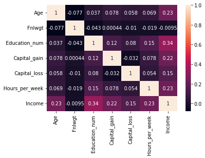

```python
sns.heatmap(data.corr(),annot=True)
```

Income has 34% correlation with ‘Education_num’, 23% correlation with ‘hours_per_week’ and ‘age’, and 22% correlation with ‘Capital_gain’. The correlations are moderate.

# Data modeling

# Replacing missing values

```python
for i in data.columns:
    print("Column :",i,",Missing Values :",data.loc[data[i] =='?',i].size)
```

```
Column : Age ,Missing Values : 0
Column : Workclass ,Missing Values : 0
Column : Fnlwgt ,Missing Values : 0
Column : Education ,Missing Values : 0
Column : Education_num ,Missing Values : 0
Column : Marital_status ,Missing Values : 0
Column : Occupation ,Missing Values : 0
Column : Relationship ,Missing Values : 0
Column : Race ,Missing Values : 0
Column : Sex ,Missing Values : 0
Column : Capital_gain ,Missing Values : 0
Column : Capital_loss ,Missing Values : 0
Column : Hours_per_week ,Missing Values : 0
Column : Native_country ,Missing Values : 0
Column : Income ,Missing Values : 0
```

```python
# Here missing values are by '?' in categorical features
```

```python
data.columns
```

```
Index(['Age', 'Workclass', 'Fnlwgt', 'Education', 'Education_num',
       'Marital_status', 'Occupation', 'Relationship', 'Race', 'Sex',
       'Capital_gain', 'Capital_loss', 'Hours_per_week', 'Native_country',
       'Income'],
      dtype='object')
```

```python
data[['Workclass','Occupation','Native_country']]
```

|  | Workclass | Occupation | Native_country |
| --- | --- | --- | --- |
| 0 | Self-emp-not-inc | Exec-managerial | United-States |
| 1 | Private | Handlers-cleaners | United-States |
| 2 | Private | Handlers-cleaners | United-States |
| 3 | Private | Prof-specialty | Cuba |
| 4 | Private | Exec-managerial | United-States |
| ... | ... | ... | ... |
| 32555 | Private | Tech-support | United-States |
| 32556 | Private | Machine-op-inspct | United-States |
| 32557 | Private | Adm-clerical | United-States |
| 32558 | Private | Adm-clerical | United-States |
| 32559 | Self-emp-inc | Exec-managerial | United-States |

32560 rows × 3 columns

```python
# maode replacement
```

```python
data['Workclass'].mode()
```

```
0     Private
dtype: object
```

```python
data['Workclass'].mode()[0]
```

```
' Private'
```

```python
data=data.replace('?',np.nan)
```

```python
for i in ['Workclass','Occupation','Native_country']:
    data[i].fillna(data[i].mode()[0], inplace=True)
```

```python
data.isin([' ?']).sum()
```

```
Age                  0
Workclass         1836
Fnlwgt               0
Education            0
Education_num        0
Marital_status       0
Occupation        1843
Relationship         0
Race                 0
Sex                  0
Capital_gain         0
Capital_loss         0
Hours_per_week       0
Native_country     583
Income               0
dtype: int64
```

```python
(data.isin([' ?']).sum()/data.shape[0])*100
```

```
Age               0.000000
Workclass         5.638821
Fnlwgt            0.000000
Education         0.000000
Education_num     0.000000
Marital_status    0.000000
Occupation        5.660319
Relationship      0.000000
Race              0.000000
Sex               0.000000
Capital_gain      0.000000
Capital_loss      0.000000
Hours_per_week    0.000000
Native_country    1.790541
Income            0.000000
dtype: float64
```

```python
data.head()
```

|  | Age | Workclass | Fnlwgt | Education | Education_num | Marital_status | Occupation | Relationship | Race | Sex | Capital_gain | Capital_loss | Hours_per_week | Native_country | Income |
| --- | --- | --- | --- | --- | --- | --- | --- | --- | --- | --- | --- | --- | --- | --- | --- |
| 0 | 50 | Self-emp-not-inc | 83311 | Bachelors | 13 | Married-civ-spouse | Exec-managerial | Husband | White | Male | 0 | 0 | 13 | United-States | 0 |
| 1 | 38 | Private | 215646 | HS-grad | 9 | Divorced | Handlers-cleaners | Not-in-family | White | Male | 0 | 0 | 40 | United-States | 0 |
| 2 | 53 | Private | 234721 | 11th | 7 | Married-civ-spouse | Handlers-cleaners | Husband | Black | Male | 0 | 0 | 40 | United-States | 0 |
| 3 | 28 | Private | 338409 | Bachelors | 13 | Married-civ-spouse | Prof-specialty | Wife | Black | Female | 0 | 0 | 40 | Cuba | 0 |
| 4 | 37 | Private | 284582 | Masters | 14 | Married-civ-spouse | Exec-managerial | Wife | White | Female | 0 | 0 | 40 | United-States | 0 |

# Encoding the data

Since majority of the classification models need input as ‘int/float’, and do not work on ‘string’ data, we encode our categorical columns using ‘Label Encoder’

```python
from sklearn.preprocessing import LabelEncoder
```

```python
le= LabelEncoder()
data.columns
```

```
Index(['Age', 'Workclass', 'Fnlwgt', 'Education', 'Education_num',
       'Marital_status', 'Occupation', 'Relationship', 'Race', 'Sex',
       'Capital_gain', 'Capital_loss', 'Hours_per_week', 'Native_country',
       'Income'],
      dtype='object')
```

```python
data['Workclass']=le.fit_transform(data['Workclass'])
data['Education']=le.fit_transform(data['Education'])
data['Marital_status']=le.fit_transform(data['Marital_status'])
data['Occupation']=le.fit_transform(data['Occupation'])
data['Relationship']=le.fit_transform(data['Relationship'])
data['Native_country']=le.fit_transform(data['Native_country'])
data['Race']=le.fit_transform(data['Race'])
data['Sex']=le.fit_transform(data['Sex'])
```

The final dataset looks something like –

```python
data.head()
```

|  | Age | Workclass | Fnlwgt | Education | Education_num | Marital_status | Occupation | Relationship | Race | Sex | Capital_gain | Capital_loss | Hours_per_week | Native_country | Income |
| --- | --- | --- | --- | --- | --- | --- | --- | --- | --- | --- | --- | --- | --- | --- | --- |
| 0 | 50 | 6 | 83311 | 9 | 13 | 2 | 4 | 0 | 4 | 1 | 0 | 0 | 13 | 39 | 0 |
| 1 | 38 | 4 | 215646 | 11 | 9 | 0 | 6 | 1 | 4 | 1 | 0 | 0 | 40 | 39 | 0 |
| 2 | 53 | 4 | 234721 | 1 | 7 | 2 | 6 | 0 | 2 | 1 | 0 | 0 | 40 | 39 | 0 |
| 3 | 28 | 4 | 338409 | 9 | 13 | 2 | 10 | 5 | 2 | 0 | 0 | 0 | 40 | 5 | 0 |
| 4 | 37 | 4 | 284582 | 12 | 14 | 2 | 4 | 5 | 4 | 0 | 0 | 0 | 40 | 39 | 0 |

# Scaling the data

The next step is to bring the data to a common scale, since there are certain columns with very small values and some columns with high values. This process is important as values on a similar scale allow the model to learn better. We use standard scaler for this process – ‘StandardScaler follows Standard Normal Distribution (SND). Therefore, it makes mean = 0 and scales the data to unit variance’

```python
from sklearn.preprocessing import StandardScaler
sc=StandardScaler()
```

```python
ds_x=data.drop('Income',axis='columns')

y=data['Income']
```

```python
dataset=sc.fit_transform(ds_x)
x = pd.DataFrame(dataset,columns=ds_x.columns)
```

# Fitting data into classification models

We now proceed to the main step of our machine learning, fitting the model and predicting the outputs. We fit the data into multiple classification models to compare the performance of all models and select the best model –

```python
# importing necessary models

from sklearn.tree import DecisionTreeClassifier
from sklearn.naive_bayes import GaussianNB
from sklearn.linear_model import LogisticRegression
from sklearn.svm import SVC
from sklearn.neighbors import KNeighborsClassifier
from sklearn.model_selection import train_test_split
from sklearn.metrics import accuracy_score,classification_report,confusion_matrix
```

```python
dt = DecisionTreeClassifier()
gnb= GaussianNB()
svc= SVC()
knn= KNeighborsClassifier()
lg= LogisticRegression()
```

```python
# fitting data into ML models and predict the output

x_train,x_test,y_train,y_test= train_test_split(x,y,test_size=0.3,random_state=11)
for i in [dt,gnb,svc,knn,lg]:
    i.fit(x_train,y_train)
    pred=i.predict(x_test)
    test_score=accuracy_score(y_test,pred)
    train_score= accuracy_score(y_train,i.predict(x_train))
    if abs(train_score - test_score)<=0.01:
        print(i)
        print('Accuracy score for train data',accuracy_score(y_test,pred))
        print('Accuracy score for test data',accuracy_score(y_train,i.predict(x_train)))
        print(classification_report(y_test,pred))
        print(confusion_matrix(y_test,pred))
        print('********************************')
```

```
GaussianNB()
Accuracy score for train data 0.8050778050778051
Accuracy score for test data 0.8001930501930502
              precision    recall  f1-score   support

           0       0.82      0.95      0.88      7412
           1       0.69      0.35      0.46      2356

    accuracy                           0.81      9768
   macro avg       0.76      0.65      0.67      9768
weighted avg       0.79      0.81      0.78      9768

[[7041  371]
 [1533  823]]
SVC()
Accuracy score for train data 0.8523751023751024
Accuracy score for test data 0.8546858546858547
              precision    recall  f1-score   support

           0       0.87      0.95      0.91      7412
           1       0.77      0.56      0.65      2356

    accuracy                           0.85      9768
   macro avg       0.82      0.75      0.78      9768
weighted avg       0.85      0.85      0.84      9768

[[7013  399]
 [1043 1313]]
LogisticRegression()
Accuracy score for train data 0.8272932022932022
Accuracy score for test data 0.8231396981396981
              precision    recall  f1-score   support

           0       0.85      0.94      0.89      7412
           1       0.72      0.46      0.56      2356

    accuracy                           0.83      9768
   macro avg       0.78      0.70      0.73      9768
weighted avg       0.82      0.83      0.81      9768

[[6991  421]
 [1266 1090]]
```

We further try fitting the data to classification models to check how our ensemble models perform on the given dataset.

```python
from sklearn.ensemble import RandomForestClassifier,AdaBoostClassifier,GradientBoostingClassifier
```

```python
rfc= RandomForestClassifier()
ad= AdaBoostClassifier()
gd = GradientBoostingClassifier()
```

```python
x_train,x_test,y_train,y_test=train_test_split(x,y,test_size= 0.3,random_state=11)
for i in[rfc,ad,gd]:
    i.fit(x_train,y_train)
    pred=i.predict(x_test)
    test_score=accuracy_score(y_test,pred)
    train_score= accuracy_score(y_train,i.predict(x_train))
    if abs(train_score-test_score)<=0.01:
        print(i)
        print('Accuracy score for train data',accuracy_score(y_test,pred))
        print('Accuracy score for test data',accuracy_score(y_train,i.predict(x_train)))
        print(classification_report(y_test,pred))
        print(confusion_matrix(y_test,pred))
        print('-----------------------')
```

```
AdaBoostClassifier()
Accuracy score for train data 0.8617936117936118
Accuracy score for test data 0.8604773604773605
              precision    recall  f1-score   support

           0       0.88      0.94      0.91      7412
           1       0.77      0.61      0.68      2356

    accuracy                           0.86      9768
   macro avg       0.83      0.78      0.80      9768
weighted avg       0.86      0.86      0.86      9768

[[6981  431]
 [ 919 1437]]
-----------------------
GradientBoostingClassifier()
Accuracy score for train data 0.8701883701883701
Accuracy score for test data 0.8671902421902422
              precision    recall  f1-score   support

           0       0.89      0.95      0.92      7412
           1       0.80      0.62      0.70      2356

    accuracy                           0.87      9768
   macro avg       0.84      0.78      0.81      9768
weighted avg       0.87      0.87      0.86      9768

[[7048  364]
 [ 904 1452]]
-----------------------
```